# Literacy 201502

coop711

2015년 9월 19일

# Data

## Excel 자료 읽어들이기

- 코딩된 excel 자료 스크린샷

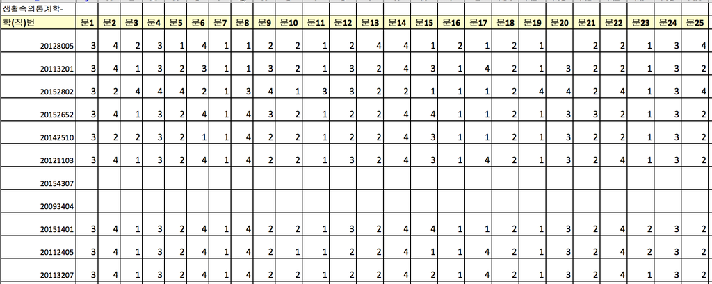

- excel 파일을 잘 읽어들이는 `xlsx` 패키지를 올려놓고, 자료구조에 맞춰 argument 설정.
  - Sheet 번호, startRow, colIndex, header 의 용도 파악.

```r
library(xlsx)
library(pander)
options(width=180)
literacy <- read.xlsx("../data/literacy_0916.xlsx", 1, startRow = 2, colIndex = c(4, 10:34), colClasses=c("numeric", rep("character", 25)), header = TRUE)
str(literacy)
```

```
## 'data.frame':    70 obs. of  26 variables:
##  $ 학.직.번: num  20128005 20113201 20152802 20152652 20142510 ...
##  $ 문1     : chr  "3" "3" "3" "3" ...
##  $ 문2     : chr  "4" "4" "2" "4" ...
##  $ 문3     : chr  "2" "1" "4" "1" ...
##  $ 문4     : chr  "3" "3" "4" "3" ...
##  $ 문5     : chr  "1" "2" "4" "2" ...
##  $ 문6     : chr  "4" "3" "2" "4" ...
##  $ 문7     : chr  "1" "1" "1" "1" ...
##  $ 문8     : chr  "1" "1" "3" "4" ...
##  $ 문9     : chr  "2" "3" "4" "3" ...
##  $ 문10    : chr  "2" "2" "1" "2" ...
##  $ 문11    : chr  "1" "1" "3" "1" ...
##  $ 문12    : chr  "2" "3" "3" "2" ...
##  $ 문13    : chr  "4" "2" "2" "2" ...
##  $ 문14    : chr  "4" "4" "2" "4" ...
##  $ 문15    : chr  "1" "3" "1" "4" ...
##  $ 문16    : chr  "2" "1" "1" "1" ...
##  $ 문17    : chr  "1" "4" "1" "1" ...
##  $ 문18    : chr  "2" "2" "2" "2" ...
##  $ 문19    : chr  "1" "1" "4" "1" ...
##  $ 문20    : chr  NA "3" "4" "3" ...
##  $ 문21    : chr  "2" "2" "2" "3" ...
##  $ 문22    : chr  "2" "2" "4" "2" ...
##  $ 문23    : chr  "1" "1" "1" "1" ...
##  $ 문24    : chr  "3" "3" "3" "3" ...
##  $ 문25    : chr  "4" "2" "4" "2" ...
```

```r
pander(head(literacy[, -1]))
```

Table continues below

| 문1 | 문2 | 문3 | 문4 | 문5 | 문6 | 문7 | 문8 |
| --- | --- | --- | --- | --- | --- | --- | --- |
| 3 | 4 | 2 | 3 | 1 | 4 | 1 | 1 |
| 3 | 4 | 1 | 3 | 2 | 3 | 1 | 1 |
| 3 | 2 | 4 | 4 | 4 | 2 | 1 | 3 |
| 3 | 4 | 1 | 3 | 2 | 4 | 1 | 4 |
| 3 | 2 | 2 | 3 | 2 | 1 | 1 | 4 |
| 3 | 4 | 1 | 3 | 2 | 4 | 1 | 4 |

Table continues below

| 문9 | 문10 | 문11 | 문12 | 문13 | 문14 | 문15 | 문16 |
| --- | --- | --- | --- | --- | --- | --- | --- |
| 2 | 2 | 1 | 2 | 4 | 4 | 1 | 2 |
| 3 | 2 | 1 | 3 | 2 | 4 | 3 | 1 |
| 4 | 1 | 3 | 3 | 2 | 2 | 1 | 1 |
| 3 | 2 | 1 | 2 | 2 | 4 | 4 | 1 |
| 2 | 2 | 1 | 2 | 2 | 4 | 3 | 1 |
| 2 | 2 | 1 | 3 | 2 | 4 | 3 | 1 |

Table continues below

| 문17 | 문18 | 문19 | 문20 | 문21 | 문22 | 문23 | 문24 |
| --- | --- | --- | --- | --- | --- | --- | --- |
| 1 | 2 | 1 | NA | 2 | 2 | 1 | 3 |
| 4 | 2 | 1 | 3 | 2 | 2 | 1 | 3 |
| 1 | 2 | 4 | 4 | 2 | 4 | 1 | 3 |
| 1 | 2 | 1 | 3 | 3 | 2 | 1 | 3 |
| 1 | 2 | 1 | 3 | 2 | 2 | 1 | 3 |
| 4 | 2 | 1 | 3 | 2 | 4 | 1 | 3 |

| 문25 |
| --- |
| 4 |
| 2 |
| 4 |
| 2 |
| 2 |
| 2 |

## 문해력 점수 계산

- 정답 맞춰보기
  - 정답 읽어들이기. `what=""`로 설정하여 `char`취급.

```r
(ans <- scan("../literacy_data/literacy_ans.txt", what=""))
```

```
##  [1] "3" "4" "1" "3" "2" "4" "1" "4" "3" "2" "1" "3" "2" "4" "3" "1" "4" "2" "1" "3" "2" "4" "1" "3" "2"
```

- 각 학생들의 답안과 맞춰보기 위하여 정답표 작성.
  - 문항별로 정답과 비교하기 위하여 각 문항을 리스트의 원소로 분리
  - `split()` 의 기능과 한계에 유의. `factor` 성격으로부터 `1, 10, 11, ..., 2, 20, ..., 3, 4, 5, ... , 9`로 순서를 잡게 되므로 다시 한번 정리할 필요.

```r
(ans.l <- split(ans, f=paste("A", 1:25, sep="")))
```

```
## $A1
## [1] "3"
##
## $A10
## [1] "2"
##
## $A11
## [1] "1"
##
## $A12
## [1] "3"
##
## $A13
## [1] "2"
##
## $A14
## [1] "4"
##
## $A15
## [1] "3"
##
## $A16
## [1] "1"
##
## $A17
## [1] "4"
##
## $A18
## [1] "2"
##
## $A19
## [1] "1"
##
## $A2
## [1] "4"
##
## $A20
## [1] "3"
##
## $A21
```

[output cut: 19 more lines]

```
##
## $A5
## [1] "2"
##
## $A6
## [1] "4"
##
## $A7
## [1] "1"
##
## $A8
## [1] "4"
##
## $A9
## [1] "3"
```

```r
(ans.l.2 <- ans.l[paste("A", 1:25, sep="")])
```

```
## $A1
## [1] "3"
##
## $A2
## [1] "4"
##
## $A3
## [1] "1"
##
## $A4
## [1] "3"
##
## $A5
## [1] "2"
##
## $A6
## [1] "4"
##
## $A7
## [1] "1"
##
## $A8
## [1] "4"
##
## $A9
## [1] "3"
##
## $A10
## [1] "2"
##
## $A11
## [1] "1"
##
## $A12
## [1] "3"
##
## $A13
## [1] "2"
##
## $A14
```

[output cut: 19 more lines]

```
##
## $A21
## [1] "2"
##
## $A22
## [1] "4"
##
## $A23
## [1] "1"
##
## $A24
## [1] "3"
##
## $A25
## [1] "2"
```

```r
# ans.mat <- matrix(rep(ans, each = nrow(literacy)), nrow = 70)
# head(ans.mat)
```

- 정답과 대조하여 R(Right)/W(Wrong) 표시
  - 채점표라는 의미의 `literacy.marks` 로 저장

```r
literacy.marks.rw <- mapply(function(x, y) factor(ifelse(x == y, "R", "W")), y = ans.l.2, literacy[, -1])
# literacy.marks <- literacy[, -1] == ans.mat
literacy.marks.rw
```

```
##       A1  A2  A3  A4  A5  A6  A7  A8  A9  A10 A11 A12 A13 A14 A15 A16 A17 A18 A19 A20 A21 A22 A23 A24 A25
##  [1,] "R" "R" "W" "R" "W" "R" "R" "W" "W" "R" "R" "W" "W" "R" "W" "W" "W" "R" "R" NA  "R" "W" "R" "R" "W"
##  [2,] "R" "R" "R" "R" "R" "W" "R" "W" "R" "R" "R" "R" "R" "R" "R" "R" "R" "R" "R" "R" "R" "W" "R" "R" "R"
##  [3,] "R" "W" "W" "W" "W" "W" "R" "W" "W" "W" "W" "R" "R" "W" "W" "R" "W" "R" "W" "W" "R" "R" "R" "R" "W"
##  [4,] "R" "R" "R" "R" "R" "R" "R" "R" "R" "R" "R" "W" "R" "R" "W" "R" "W" "R" "R" "R" "W" "W" "R" "R" "R"
##  [5,] "R" "W" "W" "R" "R" "W" "R" "R" "W" "R" "R" "W" "R" "R" "R" "R" "W" "R" "R" "R" "R" "W" "R" "R" "R"
##  [6,] "R" "R" "R" "R" "R" "R" "R" "R" "W" "R" "R" "R" "R" "R" "R" "R" "R" "R" "R" "R" "R" "R" "R" "R" "R"
##  [7,] NA  NA  NA  NA  NA  NA  NA  NA  NA  NA  NA  NA  NA  NA  NA  NA  NA  NA  NA  NA  NA  NA  NA  NA  NA
##  [8,] NA  NA  NA  NA  NA  NA  NA  NA  NA  NA  NA  NA  NA  NA  NA  NA  NA  NA  NA  NA  NA  NA  NA  NA  NA
##  [9,] "R" "R" "R" "R" "R" "R" "R" "R" "W" "R" "R" "R" "R" "R" "W" "R" "W" "R" "R" "R" "R" "R" "W" "R" "R"
## [10,] "R" "R" "R" "R" "R" "R" "R" "R" "W" "W" "R" "W" "R" "R" "W" "R" "R" "R" "R" "R" "R" "R" "W" "R" "R"
## [11,] "R" "R" "R" "R" "R" "R" "R" "R" "W" "R" "R" "W" "R" "R" "W" "R" "R" "R" "R" "R" "R" "R" "R" "R" "R"
## [12,] "R" "R" "R" "R" "R" "R" "R" "R" "R" "R" "R" "R" "R" "R" "W" "R" "R" "R" "R" "R" "R" "W" "R" "R" "R"
## [13,] "R" "R" "R" "R" "R" "R" "R" "R" "W" "R" "R" "W" "R" "R" "R" "R" "R" "R" "R" "R" "R" "W" "R" "R" "R"
## [14,] "R" "R" "W" "R" "R" "W" "R" "R" "R" "R" "R" "R" "R" "R" "R" "R" "R" "R" "R" "R" "R" "W" "R" NA  NA
```

[output cut: 56 more lines]

- 학생별 정답 갯수 산출
  - 정답을 집계하기 위하여 “R” 갯수를 다시 산출하는 `ifelse()` 적용.
  - 4점씩 곱하면 100점 만점 기준의 점수가 됨.
  - 조사표는 작성해서 제출했지만 빈칸이 있는 경우는 그 문항을 0점 처리, 결석의 경우는 점수가 모두 0으로 나오는 경우를 NA처리

```r
(literacy.marks <- ifelse(literacy.marks.rw == "R", 1, 0))
```

```
##       A1 A2 A3 A4 A5 A6 A7 A8 A9 A10 A11 A12 A13 A14 A15 A16 A17 A18 A19 A20 A21 A22 A23 A24 A25
##  [1,]  1  1  0  1  0  1  1  0  0   1   1   0   0   1   0   0   0   1   1  NA   1   0   1   1   0
##  [2,]  1  1  1  1  1  0  1  0  1   1   1   1   1   1   1   1   1   1   1   1   1   0   1   1   1
##  [3,]  1  0  0  0  0  0  1  0  0   0   0   1   1   0   0   1   0   1   0   0   1   1   1   1   0
##  [4,]  1  1  1  1  1  1  1  1  1   1   1   0   1   1   0   1   0   1   1   1   0   0   1   1   1
##  [5,]  1  0  0  1  1  0  1  1  0   1   1   0   1   1   1   1   0   1   1   1   1   0   1   1   1
##  [6,]  1  1  1  1  1  1  1  1  0   1   1   1   1   1   1   1   1   1   1   1   1   1   1   1   1
##  [7,] NA NA NA NA NA NA NA NA NA  NA  NA  NA  NA  NA  NA  NA  NA  NA  NA  NA  NA  NA  NA  NA  NA
##  [8,] NA NA NA NA NA NA NA NA NA  NA  NA  NA  NA  NA  NA  NA  NA  NA  NA  NA  NA  NA  NA  NA  NA
##  [9,]  1  1  1  1  1  1  1  1  0   1   1   1   1   1   0   1   0   1   1   1   1   1   0   1   1
## [10,]  1  1  1  1  1  1  1  1  0   0   1   0   1   1   0   1   1   1   1   1   1   1   0   1   1
## [11,]  1  1  1  1  1  1  1  1  0   1   1   0   1   1   0   1   1   1   1   1   1   1   1   1   1
## [12,]  1  1  1  1  1  1  1  1  1   1   1   1   1   1   0   1   1   1   1   1   1   0   1   1   1
## [13,]  1  1  1  1  1  1  1  1  0   1   1   0   1   1   1   1   1   1   1   1   1   0   1   1   1
## [14,]  1  1  0  1  1  0  1  1  1   1   1   1   1   1   1   1   1   1   1   1   1   0   1  NA  NA
```

[output cut: 56 more lines]

```r
(literacy.score <- apply(literacy.marks, 1, sum, na.rm = TRUE) * 4)
```

```
##  [1]  52  88  40  80  72  96   0   0  84  80  88  92  88  80  88  88   0   0   0  92  76   0  84  84  92  96  68  72  96  68  92  92  96  84  88  96   0  92  92  80  92  92 100   0
## [45]   0  88  96  92  96   0   0  96   0  84  76  96  92 100  96  88   0  88  76 100  96  84  96  88  88  92
```

```r
stem(literacy.score, scale = 2)
```

```
##
##   The decimal point is 1 digit(s) to the right of the |
##
##    0 | 0000000000000
##    1 |
##    2 |
##    3 |
##    4 | 0
##    5 | 2
##    6 | 88
##    7 | 22666
##    8 | 000044444488888888888
##    9 | 222222222222666666666666
##   10 | 000
```

```r
literacy.score[literacy.score == 0] <- NA
stem(literacy.score, scale = 1)
```

```
##
##   The decimal point is 1 digit(s) to the right of the |
##
##    4 | 0
##    5 | 2
##    6 | 88
##    7 | 22666
##    8 | 000044444488888888888
##    9 | 222222222222666666666666
##   10 | 000
```

- 문해력 등급 판정
  - 1수준(24점 이하), 2수준(28 ~ 48점), 3수준(52 ~ 72점), 4수준(76점 이상)

```r
(literacy.level <- ifelse(literacy.score <= 24, "1", ifelse(literacy.score <= 48, "2", ifelse(literacy.score <= 72, "3", "4"))))
```

```
##  [1] "3" "4" "2" "4" "3" "4" NA  NA  "4" "4" "4" "4" "4" "4" "4" "4" NA  NA  NA  "4" "4" NA  "4" "4" "4" "4" "3" "3" "4" "3" "4" "4" "4" "4" "4" "4" NA  "4" "4" "4" "4" "4" "4" NA
## [45] NA  "4" "4" "4" "4" NA  NA  "4" NA  "4" "4" "4" "4" "4" "4" "4" NA  "4" "4" "4" "4" "4" "4" "4" "4" "4"
```

```r
table("문해력 등급 분포" = literacy.level)
```

```
## 문해력 등급 분포
##  2  3  4
##  1  5 51
```

- 문항유형표 읽어들이기

```r
(type <- scan(file = "../literacy_data/literacy_type.txt", what = ""))
```

```
##  [1] "a" "a" "c" "a" "b" "b" "b" "a" "b" "b" "a" "a" "a" "b" "a" "a" "b" "c" "a" "a" "a" "c" "b" "a" "b"
```

```r
(type.kr <- factor(type, levels=c("a", "b", "c"), labels=c("사실적", "추론적", "비판적")))
```

```
##  [1] 사실적 사실적 비판적 사실적 추론적 추론적 추론적 사실적 추론적 추론적 사실적 사실적 사실적 추론적 사실적 사실적 추론적 비판적 사실적 사실적 사실적 비판적 추론적 사실적 추론적
## Levels: 사실적 추론적 비판적
```

- 유형별 점수 파악
  - 왜 `literacy.marks`의 전치행렬을 사용하고 있는지 이해 필요.
  - 변수들은 사실상 각 학생을 나타내므로 변수명을 `s1, s2, ...` 등으로 바꿈.
  - 일부 문항의 응답이 NA이면 그 문항을 0점 처리, 결석이면 NA 처리.

```r
literacy.type.score <- aggregate(t(literacy.marks), list("유형" = type.kr), sum, na.rm = TRUE)
data.frame("유형" = literacy.type.score[, 1], literacy.type.score[, 2:25]*4)
```

```
##     유형 V1 V2 V3 V4 V5 V6 V7 V8 V9 V10 V11 V12 V13 V14 V15 V16 V17 V18 V19 V20 V21 V22 V23 V24
## 1 사실적 28 48 24 40 44 52  0  0 48  44  44  48  48  48  52  52   0   0   0  48  40   0  48  44
## 2 추론적 20 32  8 32 24 32  0  0 24  24  32  36  32  28  32  28   0   0   0  32  24   0  28  32
## 3 비판적  4  8  8  8  4 12  0  0 12  12  12   8   8   4   4   8   0   0   0  12  12   0   8   8
```

```r
data.frame("유형" = literacy.type.score[, 1], literacy.type.score[, 26:48]*4)
```

```
##     유형 V25 V26 V27 V28 V29 V30 V31 V32 V33 V34 V35 V36 V37 V38 V39 V40 V41 V42 V43 V44 V45 V46 V47
## 1 사실적  44  48  36  40  52  36  48  44  48  48  44  48   0  48  48  44  52  48  52   0   0  44  52
## 2 추론적  36  36  28  24  32  28  32  36  36  28  36  36   0  32  36  24  32  32  36   0   0  32  32
## 3 비판적  12  12   4   8  12   4  12  12  12   8   8  12   0  12   8  12   8  12  12   0   0  12  12
```

```r
data.frame("유형" = literacy.type.score[, 1], literacy.type.score[, 49:71]*4)
```

```
##     유형 V48 V49 V50 V51 V52 V53 V54 V55 V56 V57 V58 V59 V60 V61 V62 V63 V64 V65 V66 V67 V68 V69 V70
## 1 사실적  44  52   0   0  52   0  40  44  52  52  52  48  44   0  48  48  52  52  44  52  48  48  48
## 2 추론적  36  32   0   0  32   0  32  20  32  28  36  36  36   0  36  20  36  36  32  32  28  32  36
## 3 비판적  12  12   0   0  12   0  12  12  12  12  12  12   8   0   4   8  12   8   8  12  12   8   8
```

```r
names(literacy.type.score)[-1] <- paste("s", 1:70, sep="")
literacy.type.score == 0
```

```
##       유형    s1    s2    s3    s4    s5    s6   s7   s8    s9   s10   s11   s12   s13   s14   s15   s16  s17  s18  s19   s20   s21  s22   s23   s24   s25   s26   s27   s28   s29
## [1,] FALSE FALSE FALSE FALSE FALSE FALSE FALSE TRUE TRUE FALSE FALSE FALSE FALSE FALSE FALSE FALSE FALSE TRUE TRUE TRUE FALSE FALSE TRUE FALSE FALSE FALSE FALSE FALSE FALSE FALSE
## [2,] FALSE FALSE FALSE FALSE FALSE FALSE FALSE TRUE TRUE FALSE FALSE FALSE FALSE FALSE FALSE FALSE FALSE TRUE TRUE TRUE FALSE FALSE TRUE FALSE FALSE FALSE FALSE FALSE FALSE FALSE
## [3,] FALSE FALSE FALSE FALSE FALSE FALSE FALSE TRUE TRUE FALSE FALSE FALSE FALSE FALSE FALSE FALSE FALSE TRUE TRUE TRUE FALSE FALSE TRUE FALSE FALSE FALSE FALSE FALSE FALSE FALSE
##        s30   s31   s32   s33   s34   s35   s36  s37   s38   s39   s40   s41   s42   s43  s44  s45   s46   s47   s48   s49  s50  s51   s52  s53   s54   s55   s56   s57   s58   s59
## [1,] FALSE FALSE FALSE FALSE FALSE FALSE FALSE TRUE FALSE FALSE FALSE FALSE FALSE FALSE TRUE TRUE FALSE FALSE FALSE FALSE TRUE TRUE FALSE TRUE FALSE FALSE FALSE FALSE FALSE FALSE
## [2,] FALSE FALSE FALSE FALSE FALSE FALSE FALSE TRUE FALSE FALSE FALSE FALSE FALSE FALSE TRUE TRUE FALSE FALSE FALSE FALSE TRUE TRUE FALSE TRUE FALSE FALSE FALSE FALSE FALSE FALSE
## [3,] FALSE FALSE FALSE FALSE FALSE FALSE FALSE TRUE FALSE FALSE FALSE FALSE FALSE FALSE TRUE TRUE FALSE FALSE FALSE FALSE TRUE TRUE FALSE TRUE FALSE FALSE FALSE FALSE FALSE FALSE
##        s60  s61   s62   s63   s64   s65   s66   s67   s68   s69   s70
## [1,] FALSE TRUE FALSE FALSE FALSE FALSE FALSE FALSE FALSE FALSE FALSE
## [2,] FALSE TRUE FALSE FALSE FALSE FALSE FALSE FALSE FALSE FALSE FALSE
## [3,] FALSE TRUE FALSE FALSE FALSE FALSE FALSE FALSE FALSE FALSE FALSE
```

```r
literacy.type.score[literacy.type.score == 0] <- NA
data.frame("유형" = literacy.type.score[, 1], literacy.type.score[, 2:25]*4)
```

```
##     유형 s1 s2 s3 s4 s5 s6 s7 s8 s9 s10 s11 s12 s13 s14 s15 s16 s17 s18 s19 s20 s21 s22 s23 s24
## 1 사실적 28 48 24 40 44 52 NA NA 48  44  44  48  48  48  52  52  NA  NA  NA  48  40  NA  48  44
## 2 추론적 20 32  8 32 24 32 NA NA 24  24  32  36  32  28  32  28  NA  NA  NA  32  24  NA  28  32
## 3 비판적  4  8  8  8  4 12 NA NA 12  12  12   8   8   4   4   8  NA  NA  NA  12  12  NA   8   8
```

```r
data.frame("유형" = literacy.type.score[, 1], literacy.type.score[, 26:48]*4)
```

```
##     유형 s25 s26 s27 s28 s29 s30 s31 s32 s33 s34 s35 s36 s37 s38 s39 s40 s41 s42 s43 s44 s45 s46 s47
## 1 사실적  44  48  36  40  52  36  48  44  48  48  44  48  NA  48  48  44  52  48  52  NA  NA  44  52
## 2 추론적  36  36  28  24  32  28  32  36  36  28  36  36  NA  32  36  24  32  32  36  NA  NA  32  32
## 3 비판적  12  12   4   8  12   4  12  12  12   8   8  12  NA  12   8  12   8  12  12  NA  NA  12  12
```

```r
data.frame("유형" = literacy.type.score[, 1], literacy.type.score[, 49:71]*4)
```

```
##     유형 s48 s49 s50 s51 s52 s53 s54 s55 s56 s57 s58 s59 s60 s61 s62 s63 s64 s65 s66 s67 s68 s69 s70
## 1 사실적  44  52  NA  NA  52  NA  40  44  52  52  52  48  44  NA  48  48  52  52  44  52  48  48  48
## 2 추론적  36  32  NA  NA  32  NA  32  20  32  28  36  36  36  NA  36  20  36  36  32  32  28  32  36
## 3 비판적  12  12  NA  NA  12  NA  12  12  12  12  12  12   8  NA   4   8  12   8   8  12  12   8   8
```

### 문항별 정답률

- 결석한 경우와 일부 문항에 답을 내지 않은 경우를 구분하는 것이 핵심.
  - `literacy.marks`를 그대로 이용하면 쉽게 계산되나, `is.na`학습 목적으로 `literacy.mark.rw`에서 출발
  - 모든 문항에 NA로 답한 결석한 학생들의 인덱스를 먼저 찾아내고,

```r
apply(literacy.marks.rw, 1, function(x) all(is.na(x)))
```

```
##  [1] FALSE FALSE FALSE FALSE FALSE FALSE  TRUE  TRUE FALSE FALSE FALSE FALSE FALSE FALSE FALSE FALSE  TRUE  TRUE  TRUE FALSE FALSE  TRUE FALSE FALSE FALSE FALSE FALSE FALSE FALSE
## [30] FALSE FALSE FALSE FALSE FALSE FALSE FALSE  TRUE FALSE FALSE FALSE FALSE FALSE FALSE  TRUE  TRUE FALSE FALSE FALSE FALSE  TRUE  TRUE FALSE  TRUE FALSE FALSE FALSE FALSE FALSE
## [59] FALSE FALSE  TRUE FALSE FALSE FALSE FALSE FALSE FALSE FALSE FALSE FALSE
```

```r
(na.all <- which(apply(literacy.marks.rw, 1, function(x) all(is.na(x)))))
```

```
##  [1]  7  8 17 18 19 22 37 44 45 50 51 53 61
```

- 정답률 계산
  - NA를 모두 오답처리한 후, 결석한 학생들만 다시 NA로 정정.
  - TRUE의 갯수를 합하여 평균.

```r
(literacy.marks.2 <- literacy.marks.rw)
```

```
##       A1  A2  A3  A4  A5  A6  A7  A8  A9  A10 A11 A12 A13 A14 A15 A16 A17 A18 A19 A20 A21 A22 A23 A24 A25
##  [1,] "R" "R" "W" "R" "W" "R" "R" "W" "W" "R" "R" "W" "W" "R" "W" "W" "W" "R" "R" NA  "R" "W" "R" "R" "W"
##  [2,] "R" "R" "R" "R" "R" "W" "R" "W" "R" "R" "R" "R" "R" "R" "R" "R" "R" "R" "R" "R" "R" "W" "R" "R" "R"
##  [3,] "R" "W" "W" "W" "W" "W" "R" "W" "W" "W" "W" "R" "R" "W" "W" "R" "W" "R" "W" "W" "R" "R" "R" "R" "W"
##  [4,] "R" "R" "R" "R" "R" "R" "R" "R" "R" "R" "R" "W" "R" "R" "W" "R" "W" "R" "R" "R" "W" "W" "R" "R" "R"
##  [5,] "R" "W" "W" "R" "R" "W" "R" "R" "W" "R" "R" "W" "R" "R" "R" "R" "W" "R" "R" "R" "R" "W" "R" "R" "R"
##  [6,] "R" "R" "R" "R" "R" "R" "R" "R" "W" "R" "R" "R" "R" "R" "R" "R" "R" "R" "R" "R" "R" "R" "R" "R" "R"
##  [7,] NA  NA  NA  NA  NA  NA  NA  NA  NA  NA  NA  NA  NA  NA  NA  NA  NA  NA  NA  NA  NA  NA  NA  NA  NA
##  [8,] NA  NA  NA  NA  NA  NA  NA  NA  NA  NA  NA  NA  NA  NA  NA  NA  NA  NA  NA  NA  NA  NA  NA  NA  NA
##  [9,] "R" "R" "R" "R" "R" "R" "R" "R" "W" "R" "R" "R" "R" "R" "W" "R" "W" "R" "R" "R" "R" "R" "W" "R" "R"
## [10,] "R" "R" "R" "R" "R" "R" "R" "R" "W" "W" "R" "W" "R" "R" "W" "R" "R" "R" "R" "R" "R" "R" "W" "R" "R"
## [11,] "R" "R" "R" "R" "R" "R" "R" "R" "W" "R" "R" "W" "R" "R" "W" "R" "R" "R" "R" "R" "R" "R" "R" "R" "R"
## [12,] "R" "R" "R" "R" "R" "R" "R" "R" "R" "R" "R" "R" "R" "R" "W" "R" "R" "R" "R" "R" "R" "W" "R" "R" "R"
## [13,] "R" "R" "R" "R" "R" "R" "R" "R" "W" "R" "R" "W" "R" "R" "R" "R" "R" "R" "R" "R" "R" "W" "R" "R" "R"
## [14,] "R" "R" "W" "R" "R" "W" "R" "R" "R" "R" "R" "R" "R" "R" "R" "R" "R" "R" "R" "R" "R" "W" "R" NA  NA
```

[output cut: 56 more lines]

```r
literacy.marks.2[is.na(literacy.marks.2)] <- "W"
literacy.marks.2[na.all, ] <- NA
literacy.marks.2 <- ifelse(literacy.marks.2 == "R", 1, 0)
options(digits=3)
(rate.by.item <- apply(literacy.marks.2, 2, mean, na.rm=TRUE)*100)
```

```
##    A1    A2    A3    A4    A5    A6    A7    A8    A9   A10   A11   A12   A13   A14   A15   A16   A17   A18   A19   A20   A21   A22   A23   A24   A25
## 100.0  93.0  80.7  98.2  93.0  77.2  98.2  93.0  59.6  93.0  96.5  47.4  96.5  98.2  82.5  89.5  68.4  94.7  94.7  89.5  82.5  66.7  91.2  96.5  89.5
```

```r
str(rate.by.item)
```

```
##  Named num [1:25] 100 93 80.7 98.2 93 ...
##  - attr(*, "names")= chr [1:25] "A1" "A2" "A3" "A4" ...
```

```r
(rate.by.item <- as.matrix(rate.by.item, 25))
```

```
##      [,1]
## A1  100.0
## A2   93.0
## A3   80.7
## A4   98.2
## A5   93.0
## A6   77.2
## A7   98.2
## A8   93.0
## A9   59.6
## A10  93.0
## A11  96.5
## A12  47.4
## A13  96.5
## A14  98.2
## A15  82.5
## A16  89.5
## A17  68.4
## A18  94.7
## A19  94.7
## A20  89.5
## A21  82.5
## A22  66.7
## A23  91.2
## A24  96.5
## A25  89.5
```

```r
dimnames(rate.by.item) <- list("문항"= paste("문", 1:25, sep=""), "정답률"="정답률")
rate.by.item
```

```
##       정답률
## 문항 정답률
##   문1   100.0
##   문2    93.0
##   문3    80.7
##   문4    98.2
##   문5    93.0
##   문6    77.2
##   문7    98.2
##   문8    93.0
##   문9    59.6
##   문10   93.0
##   문11   96.5
##   문12   47.4
##   문13   96.5
##   문14   98.2
##   문15   82.5
##   문16   89.5
##   문17   68.4
##   문18   94.7
##   문19   94.7
##   문20   89.5
##   문21   82.5
##   문22   66.7
##   문23   91.2
##   문24   96.5
##   문25   89.5
```

```r
colnames(rate.by.item) <- "정답률"
```

- 유형별 정답률 계산

```r
(rate.by.item.type <- data.frame("유형" = type.kr, "정답률" = rate.by.item))
```

```
##        유형 정답률
## 문1  사실적  100.0
## 문2  사실적   93.0
## 문3  비판적   80.7
## 문4  사실적   98.2
## 문5  추론적   93.0
## 문6  추론적   77.2
## 문7  추론적   98.2
## 문8  사실적   93.0
## 문9  추론적   59.6
## 문10 추론적   93.0
## 문11 사실적   96.5
## 문12 사실적   47.4
## 문13 사실적   96.5
## 문14 추론적   98.2
## 문15 사실적   82.5
## 문16 사실적   89.5
## 문17 추론적   68.4
## 문18 비판적   94.7
## 문19 사실적   94.7
## 문20 사실적   89.5
## 문21 사실적   82.5
## 문22 비판적   66.7
## 문23 추론적   91.2
## 문24 사실적   96.5
## 문25 추론적   89.5
```

```r
dimnames(rate.by.item.type) <- list("문항"= paste("문", 1:25, sep=""), "유형과 정답률"=c("유형", "정답률"))
rate.by.item.type
```

```
##        유형 정답률
## 문1  사실적  100.0
## 문2  사실적   93.0
## 문3  비판적   80.7
## 문4  사실적   98.2
## 문5  추론적   93.0
## 문6  추론적   77.2
## 문7  추론적   98.2
## 문8  사실적   93.0
## 문9  추론적   59.6
## 문10 추론적   93.0
## 문11 사실적   96.5
## 문12 사실적   47.4
## 문13 사실적   96.5
## 문14 추론적   98.2
## 문15 사실적   82.5
## 문16 사실적   89.5
## 문17 추론적   68.4
## 문18 비판적   94.7
## 문19 사실적   94.7
## 문20 사실적   89.5
## 문21 사실적   82.5
## 문22 비판적   66.7
## 문23 추론적   91.2
## 문24 사실적   96.5
## 문25 추론적   89.5
```

- `replace()`를 이용하면,

```r
(literacy.marks.3 <- replace(literacy.marks.rw, is.na(literacy.marks.rw), "W"))
```

```
##       A1  A2  A3  A4  A5  A6  A7  A8  A9  A10 A11 A12 A13 A14 A15 A16 A17 A18 A19 A20 A21 A22 A23 A24 A25
##  [1,] "R" "R" "W" "R" "W" "R" "R" "W" "W" "R" "R" "W" "W" "R" "W" "W" "W" "R" "R" "W" "R" "W" "R" "R" "W"
##  [2,] "R" "R" "R" "R" "R" "W" "R" "W" "R" "R" "R" "R" "R" "R" "R" "R" "R" "R" "R" "R" "R" "W" "R" "R" "R"
##  [3,] "R" "W" "W" "W" "W" "W" "R" "W" "W" "W" "W" "R" "R" "W" "W" "R" "W" "R" "W" "W" "R" "R" "R" "R" "W"
##  [4,] "R" "R" "R" "R" "R" "R" "R" "R" "R" "R" "R" "W" "R" "R" "W" "R" "W" "R" "R" "R" "W" "W" "R" "R" "R"
##  [5,] "R" "W" "W" "R" "R" "W" "R" "R" "W" "R" "R" "W" "R" "R" "R" "R" "W" "R" "R" "R" "R" "W" "R" "R" "R"
##  [6,] "R" "R" "R" "R" "R" "R" "R" "R" "W" "R" "R" "R" "R" "R" "R" "R" "R" "R" "R" "R" "R" "R" "R" "R" "R"
##  [7,] "W" "W" "W" "W" "W" "W" "W" "W" "W" "W" "W" "W" "W" "W" "W" "W" "W" "W" "W" "W" "W" "W" "W" "W" "W"
##  [8,] "W" "W" "W" "W" "W" "W" "W" "W" "W" "W" "W" "W" "W" "W" "W" "W" "W" "W" "W" "W" "W" "W" "W" "W" "W"
##  [9,] "R" "R" "R" "R" "R" "R" "R" "R" "W" "R" "R" "R" "R" "R" "W" "R" "W" "R" "R" "R" "R" "R" "W" "R" "R"
## [10,] "R" "R" "R" "R" "R" "R" "R" "R" "W" "W" "R" "W" "R" "R" "W" "R" "R" "R" "R" "R" "R" "R" "W" "R" "R"
## [11,] "R" "R" "R" "R" "R" "R" "R" "R" "W" "R" "R" "W" "R" "R" "W" "R" "R" "R" "R" "R" "R" "R" "R" "R" "R"
## [12,] "R" "R" "R" "R" "R" "R" "R" "R" "R" "R" "R" "R" "R" "R" "W" "R" "R" "R" "R" "R" "R" "W" "R" "R" "R"
## [13,] "R" "R" "R" "R" "R" "R" "R" "R" "W" "R" "R" "W" "R" "R" "R" "R" "R" "R" "R" "R" "R" "W" "R" "R" "R"
## [14,] "R" "R" "W" "R" "R" "W" "R" "R" "R" "R" "R" "R" "R" "R" "R" "R" "R" "R" "R" "R" "R" "W" "R" "W" "W"
```

[output cut: 56 more lines]

```r
literacy.marks.3[na.all, ] <- NA
literacy.marks.3
```

```
##       A1  A2  A3  A4  A5  A6  A7  A8  A9  A10 A11 A12 A13 A14 A15 A16 A17 A18 A19 A20 A21 A22 A23 A24 A25
##  [1,] "R" "R" "W" "R" "W" "R" "R" "W" "W" "R" "R" "W" "W" "R" "W" "W" "W" "R" "R" "W" "R" "W" "R" "R" "W"
##  [2,] "R" "R" "R" "R" "R" "W" "R" "W" "R" "R" "R" "R" "R" "R" "R" "R" "R" "R" "R" "R" "R" "W" "R" "R" "R"
##  [3,] "R" "W" "W" "W" "W" "W" "R" "W" "W" "W" "W" "R" "R" "W" "W" "R" "W" "R" "W" "W" "R" "R" "R" "R" "W"
##  [4,] "R" "R" "R" "R" "R" "R" "R" "R" "R" "R" "R" "W" "R" "R" "W" "R" "W" "R" "R" "R" "W" "W" "R" "R" "R"
##  [5,] "R" "W" "W" "R" "R" "W" "R" "R" "W" "R" "R" "W" "R" "R" "R" "R" "W" "R" "R" "R" "R" "W" "R" "R" "R"
##  [6,] "R" "R" "R" "R" "R" "R" "R" "R" "W" "R" "R" "R" "R" "R" "R" "R" "R" "R" "R" "R" "R" "R" "R" "R" "R"
##  [7,] NA  NA  NA  NA  NA  NA  NA  NA  NA  NA  NA  NA  NA  NA  NA  NA  NA  NA  NA  NA  NA  NA  NA  NA  NA
##  [8,] NA  NA  NA  NA  NA  NA  NA  NA  NA  NA  NA  NA  NA  NA  NA  NA  NA  NA  NA  NA  NA  NA  NA  NA  NA
##  [9,] "R" "R" "R" "R" "R" "R" "R" "R" "W" "R" "R" "R" "R" "R" "W" "R" "W" "R" "R" "R" "R" "R" "W" "R" "R"
## [10,] "R" "R" "R" "R" "R" "R" "R" "R" "W" "W" "R" "W" "R" "R" "W" "R" "R" "R" "R" "R" "R" "R" "W" "R" "R"
## [11,] "R" "R" "R" "R" "R" "R" "R" "R" "W" "R" "R" "W" "R" "R" "W" "R" "R" "R" "R" "R" "R" "R" "R" "R" "R"
## [12,] "R" "R" "R" "R" "R" "R" "R" "R" "R" "R" "R" "R" "R" "R" "W" "R" "R" "R" "R" "R" "R" "W" "R" "R" "R"
## [13,] "R" "R" "R" "R" "R" "R" "R" "R" "W" "R" "R" "W" "R" "R" "R" "R" "R" "R" "R" "R" "R" "W" "R" "R" "R"
## [14,] "R" "R" "W" "R" "R" "W" "R" "R" "R" "R" "R" "R" "R" "R" "R" "R" "R" "R" "R" "R" "R" "W" "R" "W" "W"
```

[output cut: 56 more lines]

- 어떤 문항의 정답률이 유난히 낮은가?

```r
rate.by.item[which(rate.by.item <= 80)]
```

```
## [1] 77.2 59.6 47.4 68.4 66.7
```

```r
rate.by.item[which(rate.by.item <= 70)]
```

```
## [1] 59.6 47.4 68.4 66.7
```

```r
rate.by.item[which(rate.by.item <= 60)]
```

```
## [1] 59.6 47.4
```

## Data 정리

```r
save.image("literacy_201502v2.rda")
```